# Reproducible Research: Peer Assessment 1

## Loading and preprocessing the data

We unzip the zip file and read it in as a CSV file.

```r
unzip(zipfile="activity.zip")
df<-read.csv(file="activity.csv")
```

We then explore the basic structure of the dataset.

```r
str(df)
```

```
## 'data.frame':    17568 obs. of  3 variables:
##  $ steps   : int  NA NA NA NA NA NA NA NA NA NA ...
##  $ date    : chr  "2012-10-01" "2012-10-01" "2012-10-01" "2012-10-01" ...
##  $ interval: int  0 5 10 15 20 25 30 35 40 45 ...
```

```r
summary(df)
```

```
##      steps            date              interval
##  Min.   :  0.00   Length:17568       Min.   :   0.0
##  1st Qu.:  0.00   Class :character   1st Qu.: 588.8
##  Median :  0.00   Mode  :character   Median :1177.5
##  Mean   : 37.38                      Mean   :1177.5
##  3rd Qu.: 12.00                      3rd Qu.:1766.2
##  Max.   :806.00                      Max.   :2355.0
##  NA's   :2304
```

## What is mean total number of steps taken per day?

Find the total number of steps taken each day, disregarding missing values.

```r
stepsByDay<-aggregate(formula=steps~date, data=df, FUN=sum, na.rm=TRUE)
```

Make a histogram of the total number of steps taken each day.

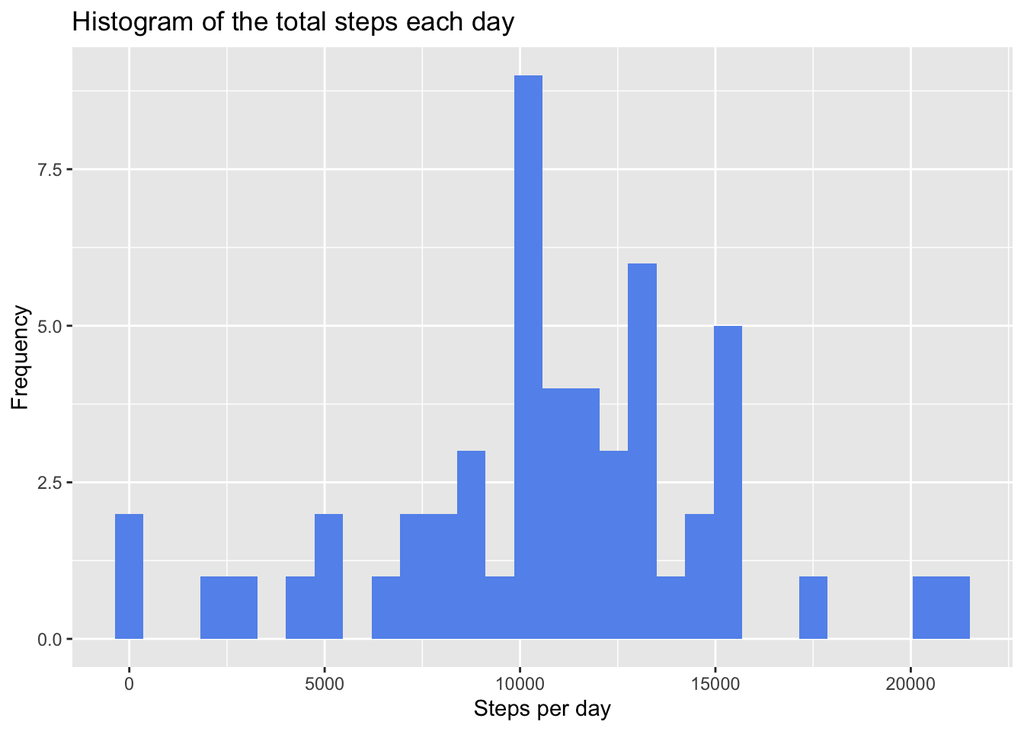

```r
library(ggplot2)

g1<-ggplot(data=stepsByDay, mapping=aes(x=steps))
plot1<-g1+geom_histogram(fill="cornflowerblue")+labs(x="Steps per day", y="Frequency", title="Histogram of the total steps each day")
print(plot1)
```

Find the mean and median of the total number of steps per day.

```r
meanSteps<-mean(stepsByDay$steps)
medianSteps<-median(stepsByDay$steps)

print(paste("Mean steps:", meanSteps))
```

```
## [1] "Mean steps: 10766.1886792453"
```

```r
print(paste("Median steps:", medianSteps))
```

```
## [1] "Median steps: 10765"
```

## What is the average daily activity pattern?

Make a time series plot of the average number of steps taken in each interval, disregarding missing values.

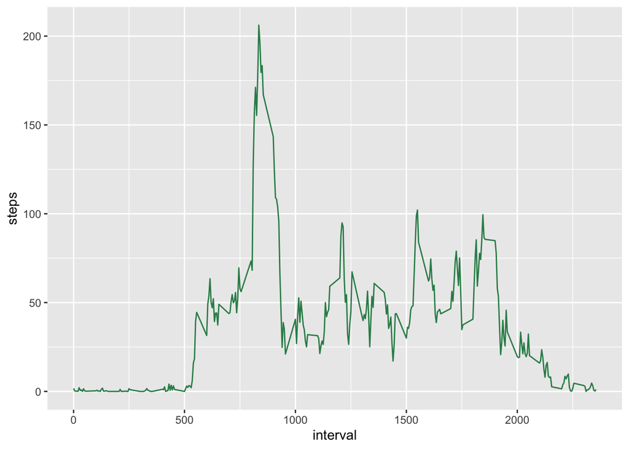

```r
stepsByInterval<-aggregate(formula=steps~interval, data=df, FUN=mean, na.rm=TRUE)

g2<-ggplot(data=stepsByInterval, mapping=aes(x=interval, y=steps))
plot2<-g2+geom_line(color="seagreen")
print(plot2)
```

Find the interval containing the maximum number of steps.

```r
maxInterval<-stepsByInterval[which.max(stepsByInterval$steps), ]$interval

print(paste("Interval with the maximum number of steps:", maxInterval))
```

```
## [1] "Interval with the maximum number of steps: 835"
```

## Imputing missing values

Find the total number of rows with missing values in the dataset.

```r
missingTotal<-sum(is.na(df$steps))

print(paste("Number of rows with missing values:", missingTotal))
```

```
## [1] "Number of rows with missing values: 2304"
```

Devise a strategy for filling in these missing values. We’ll fill in a given missing value with the mean number of steps that day, where the mean is calculated from non-missing data. Here’s the function to fill in an individual missing value.

```r
meanStepsByDay<-aggregate(formula=steps~date, data=df, FUN=mean, na.rm=TRUE)

fillNA<-function(day, meanStepsByDay=meanStepsByDay) {
        filledValue<-meanStepsByDay[meanStepsByDay$date==day, ]$steps
        if(identical(filledValue, numeric(length=0))) {
                return(0)
        } else {
                return(filledValue)
        }
}
```

Create a new dataset with missing values imputed.

```r
newDf<-df

for(i in 1:nrow(newDf)) {
        if(is.na(newDf[i, ]$steps)) {
                newDf[i, ]$steps<-fillNA(day=newDf[i, ]$date, meanStepsByDay=meanStepsByDay)
        }
}
```

Make a histogram of the total number of steps each day for the imputed dataset.

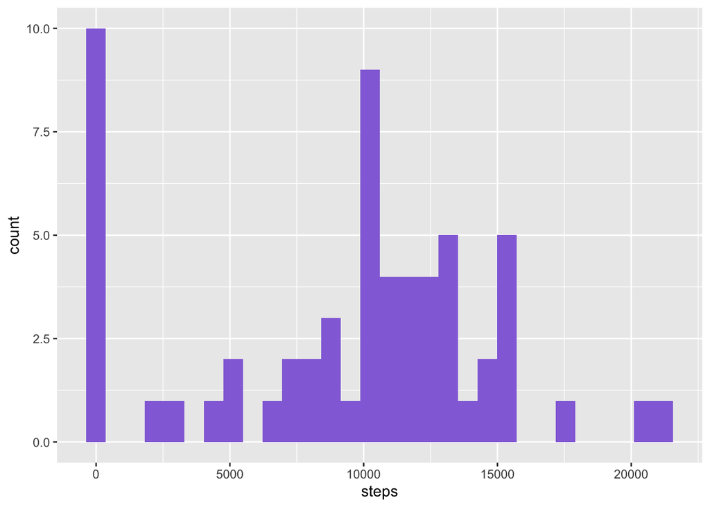

```r
stepsByDayImputed<-aggregate(formula=steps~date, data=newDf, FUN=sum)

g3<-ggplot(data=stepsByDayImputed, mapping=aes(x=steps))
plot3<-g3+geom_histogram(fill="mediumpurple")
print(plot3)
```

Find the mean and median steps taken per day for the imputed dataset.

```r
meanStepsImputed<-mean(stepsByDayImputed$steps)
medianStepsImputed<-median(stepsByDayImputed$steps)

print(paste("Mean steps for the imputed dataset:", meanStepsImputed))
```

```
## [1] "Mean steps for the imputed dataset: 9354.22950819672"
```

```r
print(paste("This mean is lesser than the original mean by:", (meanSteps-meanStepsImputed)))
```

```
## [1] "This mean is lesser than the original mean by: 1411.95917104856"
```

```r
print(paste("Median steps for the imputed dataset:", medianStepsImputed))
```

```
## [1] "Median steps for the imputed dataset: 10395"
```

```r
print(paste("This median is lesser than the original median by:", (medianSteps-medianStepsImputed)))
```

```
## [1] "This median is lesser than the original median by: 370"
```

## Are there differences in activity patterns between weekdays and weekends?

Create a new factor variable indicating whether days are weekdays or weekends.

```r
newDf$date<-as.Date(strptime(x=newDf$date, format="%Y-%m-%d"))
newDf$day<-weekdays(newDf$date)

for(i in 1:nrow(newDf)) {
        if(newDf[i, ]$day %in% c("Saturday", "Sunday")) {
                newDf[i, ]$day<-"weekend"
        } else {
                newDf[i, ]$day<-"weekday"
        }
}
```

Make a time series plot showing the number of steps for weekdays and weekends.

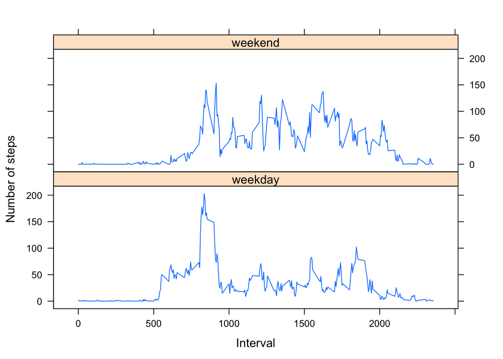

```r
library(lattice)
stepsByWeekday<-aggregate(formula=steps~interval+day, data=newDf, FUN=mean)
xyplot(x=steps~interval|day, data=stepsByWeekday, type="l", layout=c(1, 2), xlab="Interval", ylab="Number of steps")
```